# Microarray Data Axin+ vs. Axin- in colon - Reanalysis with LIMMA

Hilmar Berger

27 May, 2019 13:06:08

# 1 Introduction

This is data from a mouse experiment (Axin2+ vs. Axin2- cells ) hybridized as dual channel to Agilent 014568 micro array.

# 2 Data overview

### 2.0.1 Samples

|  | Chip.Barcode | dye_swap | Cy3 | Cy5 |
| --- | --- | --- | --- | --- |
| US22502595_251486841828_S01_GE2_1105_Oct12_1_3 | 251486841828_1_3 | FALSE | Axin- | Axin+ |
| US22502595_251486841828_S01_GE2_1105_Oct12_1_4 | 251486841828_1_4 | TRUE | Axin+ | Axin- |

## 2.1 Raw data

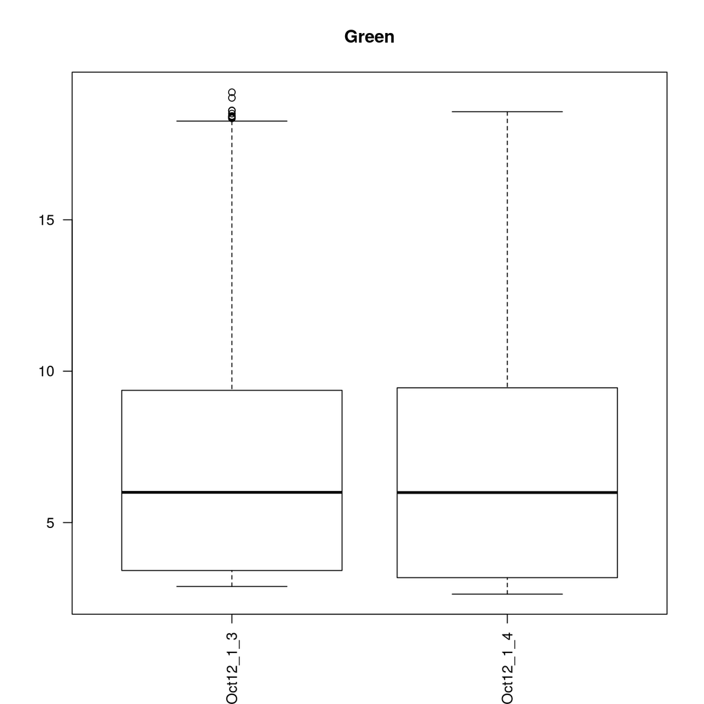

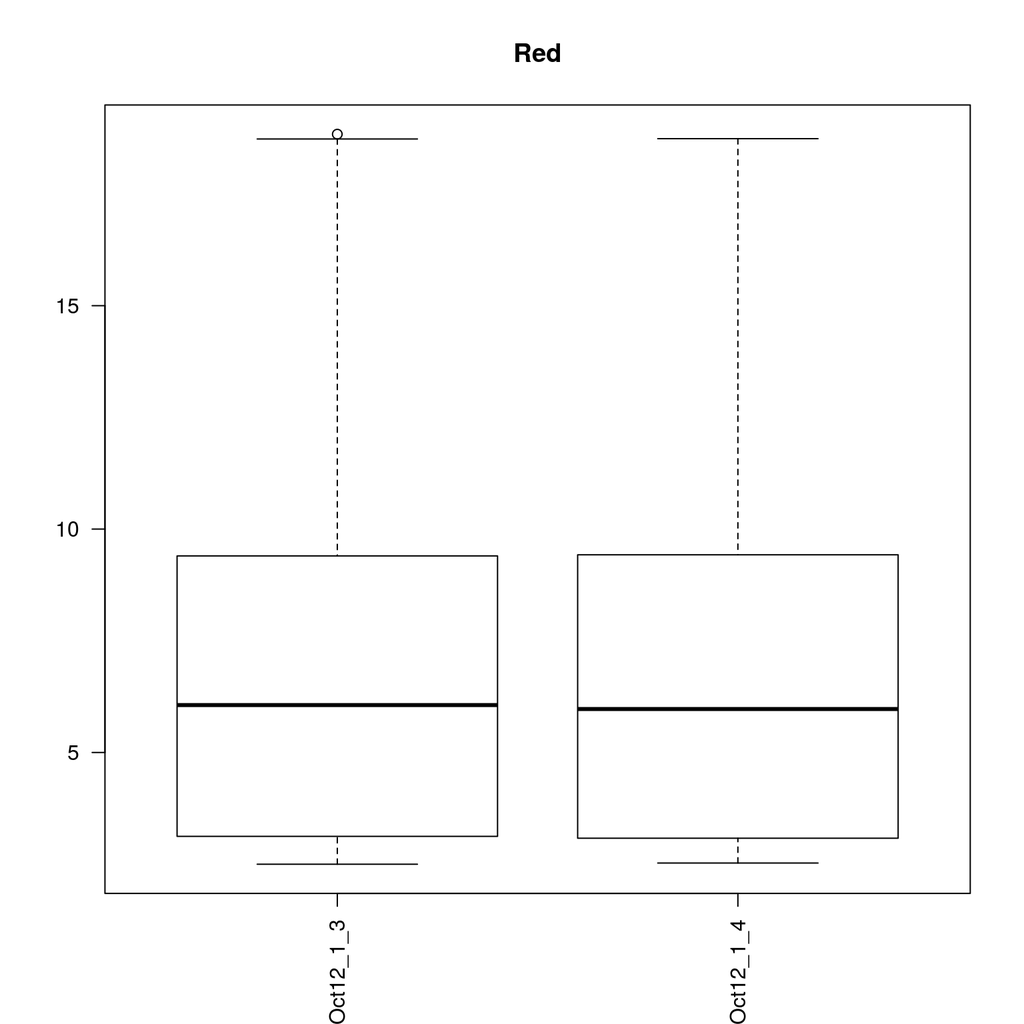

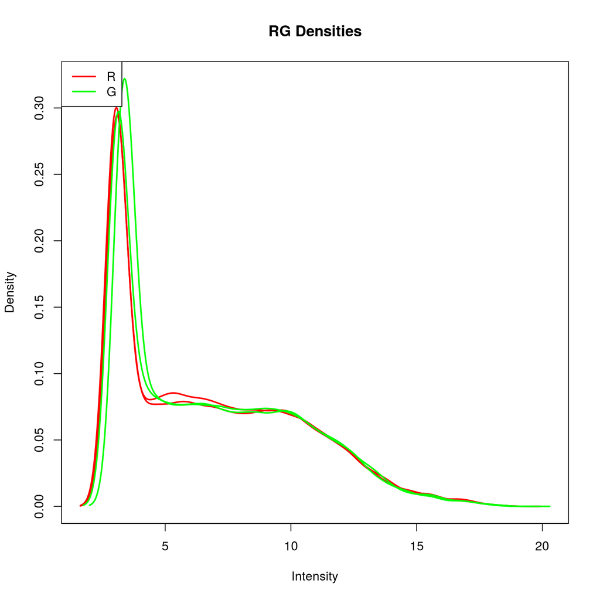

# 3 Within-array normalization

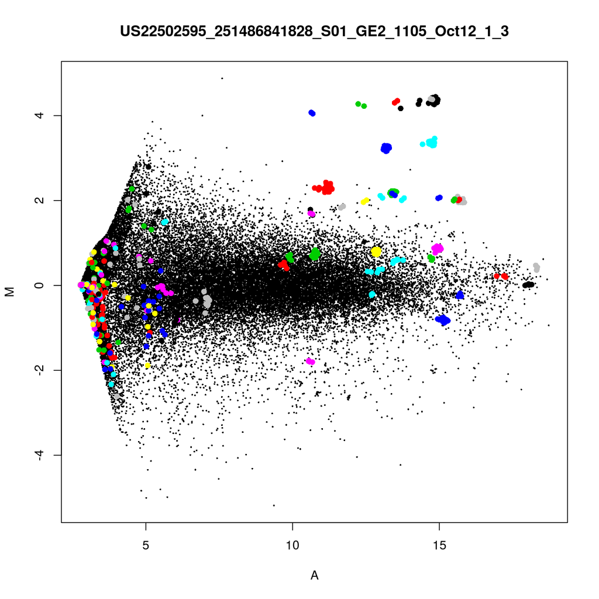

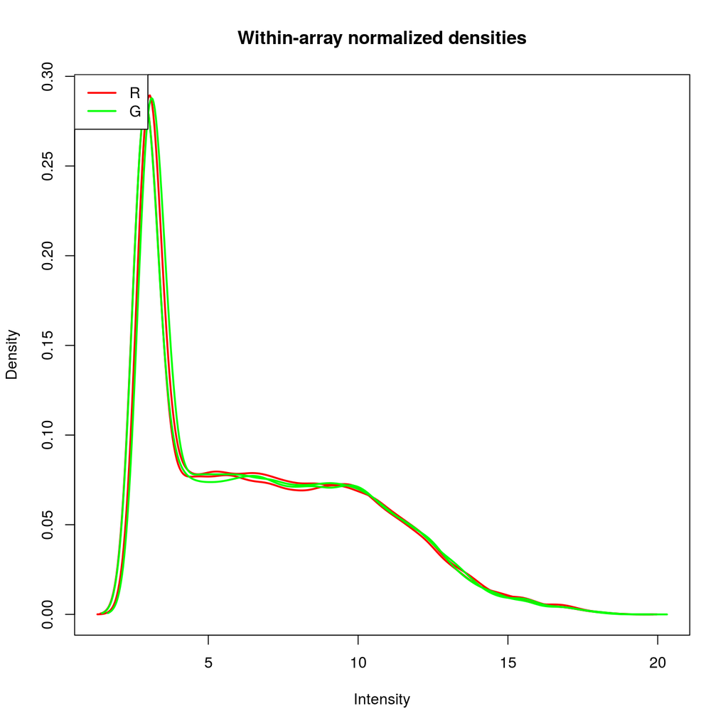

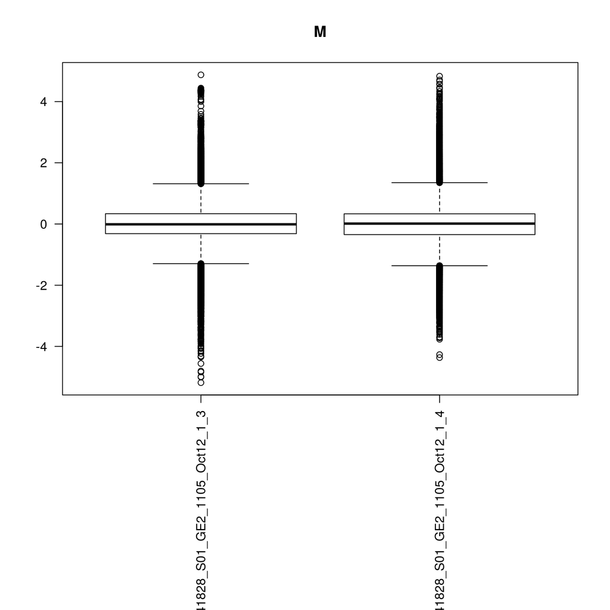

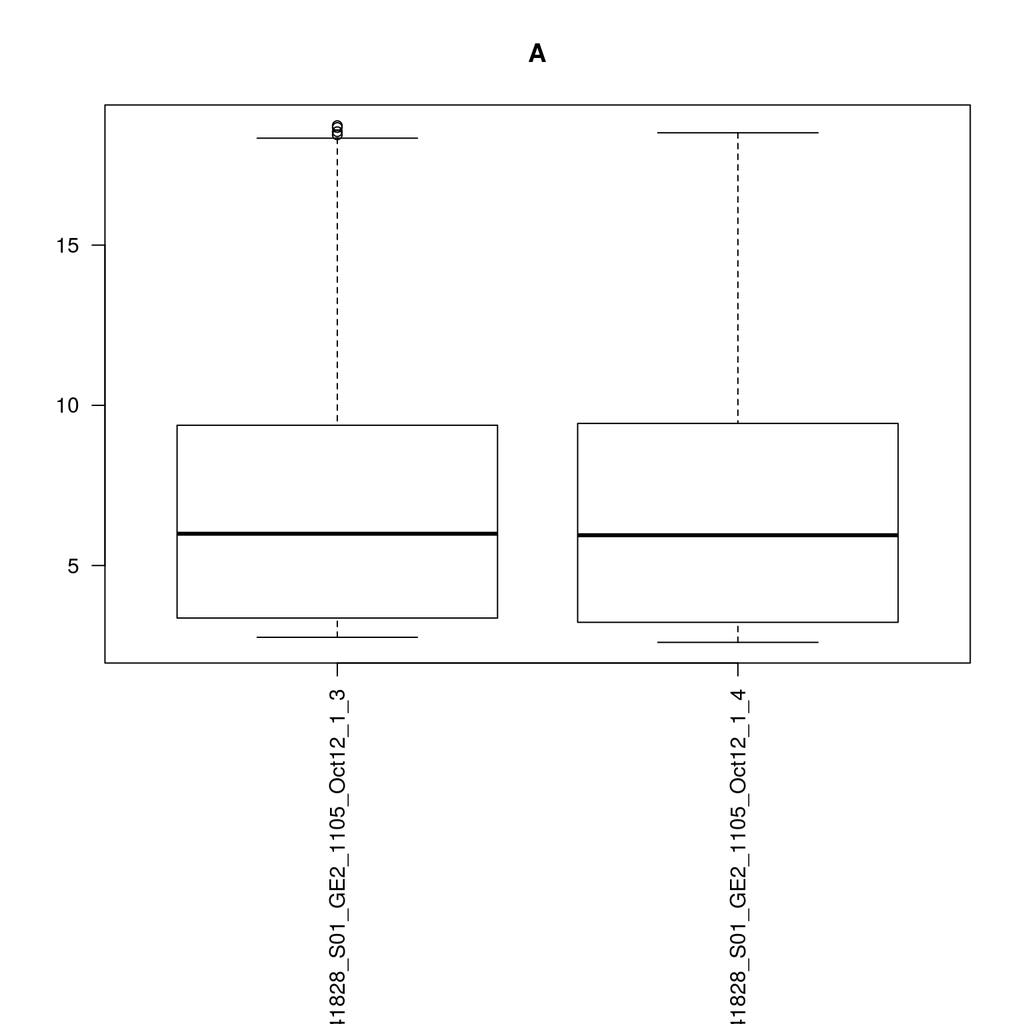

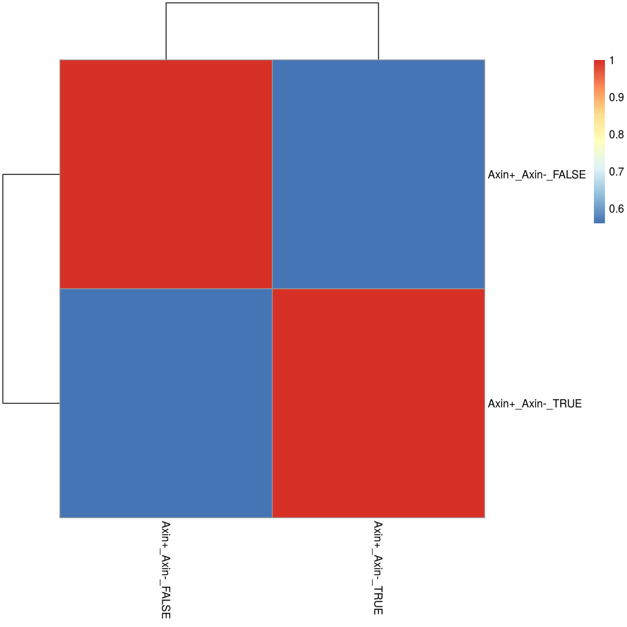

# 4 Axin2 expression in samples

M-value is the difference between two conditions (R minus G channels or G minus R, depending on dye swap ) for a probe.

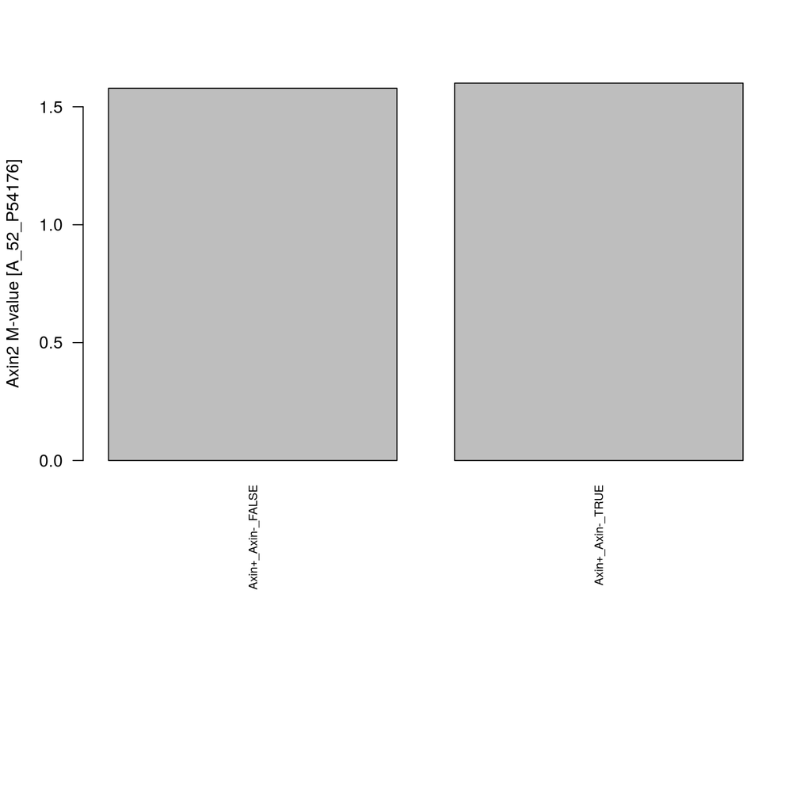

As expected the sorted Axin2+ cells show higher Axin2 expression than Axin2- cells.

## 4.1 Control probes

The following control probes exist on the arrays used in this experiment:

- Corner associated (used for orientation purposes during scanning)
- Bright corner
- Dark corner
- Negative controls
- 3xSLv1 (hairpin probe that does not hybridize well with any possible RNA)
- Positive controls
- Human GAPDH and PGK1 probes
- Deletion stringency probes (DCP, probe with varying number of insertions/changes with respect to reference; the number after the “_" denotes the number of differences to the reference which should correlate with lower expression)
- E1A_r60: spike-in probes with concentrations that should cover the whole dynamic range of the array

There are a few other expression probes that are used by Agilent’s feature extraction/QC pipeline.

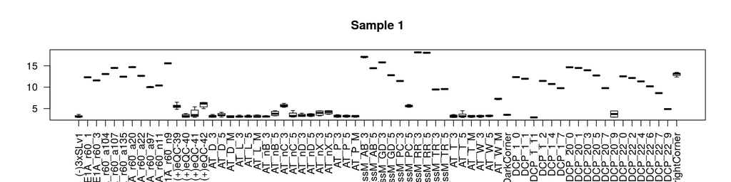

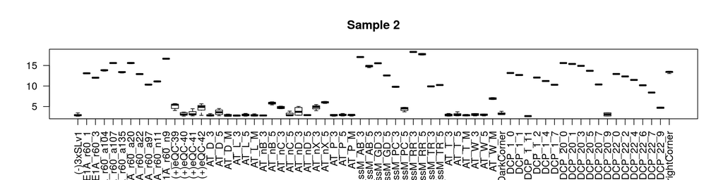

```r
ed=ed_orig
save(ed, RG, MA,  file="../../Data/Processed/Axin_Colon_micro_array_preprocessed_data.Rdata")
```

# 5 Software versions